# Text Analysis with R

Wouter van Atteveldt  
VU-HPC, 20167-11-05

### Course Overview

9:00 - 10:30

- R as a data analysis evironment
- Frequency Based Analysis and the DTM
- Dictionary Analysis with AmCAT and R

11:00 - 13:00

- Simple Natural Language Processing
- Corpus Analysis and Visualization
- Topic Modeling and Visualization
- Please install R+Rstudio now! `:-)`

## R as a data analysis environment

### Why R?

- Open source, active community
- Native vector/matrix calculus
- Slow, but modules mostly in C or Fortran
- R vs Python
  - Strongly converging (numpy/pandas)
  - Python more 'programming', R more 'statistics'
- R vs SPSS
  - …

### R basics

- Functionality in packages
  - `install.packages("quanteda")`
  - `library(quanteda)`
  - OR: `quanteda::dfm(..)`
- Lazy evaluation, functions are objects, (most) functions don't change arguments, most functions apply to vectors

### R primitives

- Basic variables are *vectors* of numbers, texts, etc
  - `c(1,2,3)`, `1:3`, `c("a", "b")`
- Data frames are a named list of columns (vectors)
- Subsetting: `a[elements]` or `a[rows, columns]`
- Element selection: `d$column`

### Some R Packages

- `stringr` - basic string manipulation
- `quanteda` - bag-of-words text analysis
- `readtext` - reading text in various formats
- `topicmodels` - topic modeling
- `corpustools` - tokenlist text analysis

### RStudio

- Shell around R
- Use projects to organize scripts+data
- R-markdown and R-presentation to weave code and data

## Frequency Based Analysis: The DTM

### Frequency Based Analysis

- Analysis based on word frequency only
  - “Bag of words” assumption
  - Ignore grammar, proximity, relations, …
- Main data: Document-term matrix (dtm)
- Can also use other features (dfm)
  - Bag of stems, lemmata, word pairs, …

### Creating a DTM

1. Text source
   - Text files
   - Data frames / vectors or text
   - External sources/APIs
2. Preprocessing
   - Stemming, lowercasing, lemmatizing
   - Collocations
3. Feature selection
   - Frequency
   - Stopwords

### Creating a DTM from text

```r
library(quanteda)
texts=c("This is a test", "They tested a test", "I found a test!")
dfm(texts)
```

```
Document-feature matrix of: 3 documents, 9 features (51.9% sparse).
3 x 9 sparse Matrix of class "dfmSparse"
       features
docs    this is a test they tested i found !
  text1    1  1 1    1    0      0 0     0 0
  text2    0  0 1    1    1      1 0     0 0
  text3    0  0 1    1    0      0 1     1 1
```

### Reading texts from file (or URL)

```r
library(readtext)
filepath <- "http://bit.ly/2uhqjJE?.csv"
t <- readtext(filepath, text_field = 'texts')
dfm(t$text)
```

```
Document-feature matrix of: 5 documents, 1,948 features (69.5% sparse).
```

### Preprocessing: stemming, stopword removal

```r
dfm(texts, stem=T, remove=stopwords("english"))
```

```
Document-feature matrix of: 3 documents, 3 features (44.4% sparse).
3 x 3 sparse Matrix of class "dfmSparse"
       features
docs    test found !
  text1    1     0 0
  text2    2     0 0
  text3    1     1 1
```

### Feature selection

```r
dfm = dfm(texts, stem=T)
dfm = dfm_trim(dfm, min_doc = 2)
dfm
```

```
Document-feature matrix of: 3 documents, 2 features (0% sparse).
3 x 2 sparse Matrix of class "dfmSparse"
       features
docs    a test
  text1 1    1
  text2 1    2
  text3 1    1
```

### More control: quanteda step-by-step

```r
tokens = tokenize(texts, remove_punct = T)
tokens = toLower(tokens)
tokens = tokens_wordstem(tokens, "english")
dfm = dfm(tokens)
dfm = dfm_select(dfm, stopwords("english"), "remove")
dfm = dfm_trim(dfm, min_count = 1)
dfm
```

```
Document-feature matrix of: 3 documents, 2 features (33.3% sparse).
3 x 2 sparse Matrix of class "dfmSparse"
       features
docs    test found
  text1    1     0
  text2    2     0
  text3    1     1
```

### Preprocessing: collocations

```r
coll = textstat_collocations(tokens)
head(coll)
```

```
  collocation count length   lambda        z
1      a test     3      2 3.245193 1.833062
```

### Preprocessing: collocations

```r
compounded = tokens_compound(tokens, coll)
dfm(compounded)
```

```
Document-feature matrix of: 3 documents, 7 features (57.1% sparse).
3 x 7 sparse Matrix of class "dfmSparse"
       features
docs    this is a_test they test i found
  text1    1  1      1    0    0 0     0
  text2    0  0      1    1    1 0     0
  text3    0  0      1    0    0 1     1
```

### (De-)Motivational example: Dutch stemming

```r
dfm_nl = dfm(c("De kippen eten", "De kip heeft gegeten"), remove=stopwords("dutch"))
dfm_nl
```

```
Document-feature matrix of: 2 documents, 4 features (50% sparse).
2 x 4 sparse Matrix of class "dfmSparse"
       features
docs    kippen eten kip gegeten
  text1      1    1   0       0
  text2      0    0   1       1
```

```r
dfm_wordstem(dfm_nl, language="dutch")
```

```
Document-feature matrix of: 2 documents, 4 features (50% sparse).
2 x 4 sparse Matrix of class "dfmSparse"
       features
docs    kipp eten kip geget
  text1    1    1   0     0
  text2    0    0   1     1
```

(We will cover lemmatizing and POS-tagging this afternoon!)

## Dictionary-based analysis

### Dictionary-based analysis

- Use list of keywords to define a concept
- (words, wildcards, boolean combinations, phrases, etc.)
- Measure (co-)occurrence of these concepts

Advantages of dictionaries?

- Easy to explain
- Easy to use
- Control over operationalization

### AmCAT

- Free and Open Source text analysis infrastructure
- Easy corpus management, keyword queries
- Integrates with R / quanteda
- Run your own server or use ours (amcat.nl)

## AmCAT demo

### Connecting to AmCAT from R

```r
devtools::install_github("amcat/amcat-r")
library(amcatr)
amcat.save.password("https://amcat.nl", username="...",
                    password="...")
```

```r
conn = amcat.connect("https://amcat.nl")
meta = amcat.articles(conn, project=1235, articleset=32114, dateparts = T)
table(meta$medium)
```

```
      The New York Times The New York Times Blogs                USA TODAY
                    9551                     1660                     1993
```

```r
saveRDS(meta, "meta.rds")
```

### Running AmCAT queries in R

```r
a = amcat.aggregate(conn, sets=32139, queries = c("trump", "clinton"), axis1 = "week")
head(a)
```

```
  count       week query
1    14 2015-12-28 trump
2    51 2016-01-04 trump
3    65 2016-01-11 trump
4    66 2016-01-18 trump
5    92 2016-01-25 trump
6    94 2016-02-01 trump
```

### Running AmCAT queries in R

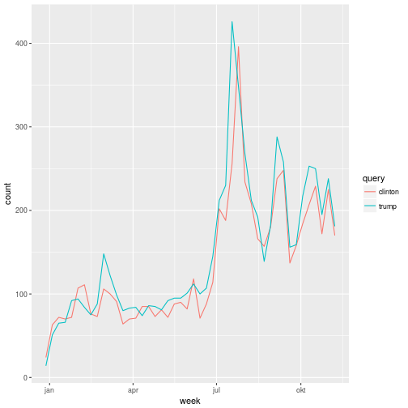

```r
library(ggplot2)
ggplot(data=a, mapping=aes(x=week, y=count, color=query)) + geom_line()
```

### Getting AmCAT data into R

```r
h = amcat.hits(conn, sets=32142,
               queries=c("trump", "clinton"))
meta = amcat.articles(conn, project=1235,
                      articleset=32142)
h = merge(meta, h)
head(h)
```

```
         id       date             medium count   query
1 162317450 2016-03-01 The New York Times     1 clinton
2 162317731 2016-02-02 The New York Times     7   trump
3 162317731 2016-02-02 The New York Times     4 clinton
4 162317809 2016-01-25 The New York Times     1   trump
5 162317820 2016-01-24 The New York Times     1 clinton
6 162317856 2016-01-18 The New York Times     1   trump
```

### Getting AmCAT texts into R

```r
articles = amcat.articles(conn, project=1235,
  articleset=32142, dateparts=T,
  columns=c("date", "headline", "text"))
saveRDS(articles, "articles.rds")
articles$text[1]
```

```
[1] "WASHINGTON -- IT'S hard not to feel sorry for Hillary Clinton. She is hearing\nghostly footsteps.\n\nShe's having her inevitability challenged a second time by a moralizing senator\nwith few accomplishments who chides her on her bad judgment on Iraq and\nspecial-interest money, breezily rakes i…
```

### AmCAT and quanteda

```r
d = dfm(articles$text, stem=T,
        remove=stopwords("english"), remove_punct=T)
d = dfm_trim(d, min_doc=10)
topfeatures(d)
```

```
        mr      trump       said    clinton        new      state
      9553       5568       4970       3565       2749       2175
       one republican        mrs      polit
      2100       2078       2030       1955
```

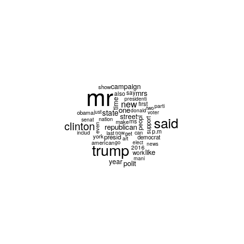

```r
textplot_wordcloud(d, max.words = 50, scale = c(4, 0.5))
```

### AmCAT and quanteda (2)

```r
c = quanteda.corpus(conn, project=1235, articleset=32142, dateparts=T)
d = dfm(c, remove=stopwords("english"))
head(d)
```

```
Document-feature matrix of: 6 documents, 6 features (52.8% sparse).
6 x 6 sparse Matrix of class "dfmSparse"
           features
docs        washington  - hard feel sorry hillary
  171937712          1  4    1    1     3       9
  171937755          2 27    1    1     0       0
  171933722          0 36    2    0     0       0
  171937938          0  0    0    0     0       0
  171937818          0  3    0    0     0       1
  171940575          1  2    0    0     0       1
```

### Dictionares within R

```r
issues = dictionary(list(economy=c("econ*", "inflation"), immigration=c("immigr*", "mexican*")))
d2 = dfm_lookup(d, issues, exclusive=T)
tail(d2)
```

```
Document-feature matrix of: 6 documents, 2 features (83.3% sparse).
6 x 2 sparse Matrix of class "dfmSparse"
           features
docs        economy immigration
  171937494       0           2
  171937704       0           0
  171944064       0           0
  171943751       0           0
  171941697       7           0
  171943991       0           0
```

### Dictionares within R

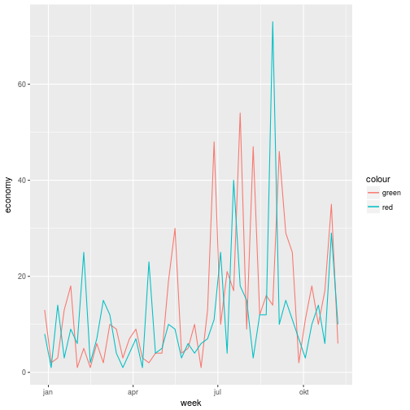

```r
d2 = cbind(docvars(c), as.matrix(d2))
a = aggregate(d2[names(issues)], d2["week"], sum)
ggplot(a, aes(x=week)) +
  geom_line(aes(y = economy, color="green"))  +
  geom_line(aes(y = immigration, color="red"))
```

### Where to get dictionaries?

- Create your own
- Create from corpora (next session)
- Replication materials
- wordstat, LIWC, …

### Hands-on session I

- Why did Trump win the (primary) election?
- Operationalize a variable using search strings
  - candidates, issues, emotion, populism, …
  - download or create word list
- Plot variable over time / co-occurring with either candidate
- Use AmCAT GUI, AmCAT R, quanteda, …